# Essay 6: Time series Volatility and ARCH Modeling

Dhruvi, Vi, Huy, Harshal

4/26/2021

## (1) INTRODUCTION

### ARCH modeling

**ARCH** models stands for Auto-Regressive Conditional Heteroskedasticity, which works with time-varying variances that relies on lagged effects. Basically, **ARCH** often deals with stationary (time-invariant mean) and non-stationary (time-varying mean) variables. This model has gain popularity in finance as a way to model the changes in the volatility of asset returns.

Consider the auto-regressive AR(1) model:
$$Y_t = \phi + e_t \qquad [1] \\
e_t|I_{t-1} \sim N(0,h_t) \qquad[2] \\
h_t = \alpha_0 + \alpha_1e^2_{t-1}, \quad a_0 > 0, \quad 0 \leq \alpha_1 < 1 \quad [3]$$
Equation [1] is described as **the mean equation** while equation [2] and [3] present the autoregressive conditional heteroskedastic class of models.

To test for ARCH effects in a time series in both test model and hypotheses, we use a Langrange multiplier (LM) test to test for the presence of ARCH effects:
$$\hat{e}^2_t = \gamma_0 + \gamma_1\hat{e}^2_{t-1} +...+ \gamma_q\hat{e}^2_{t-q} + \nu$$
in which: + $\hat{e}_t$: the estimated residuals + $\hat{e}^2_{t-1}$: the squared residuals lagged + $\chi_t$: a random error term

and the null and alternative hypotheses are:
$$H_0 : \gamma_1 = ... = \gamma_q \quad ; \quad H_A : \gamma_1 \ne or ... \gamma_q \ne 0$$

If there are no ARCH effects, the $\gamma_1 = 0$ and the fit of the mean equation will be poor, and the equation $R^2$ will be low. Otherwise, if there exists ARCH effects, then $|\hat{e}^2_t|$ depends on its lagged value and $R^2$ is relatively high.

The LM test statistic is:
$$(T-q)R^2 \sim \chi^2_{1-\alpha,q}$$
in which: + *T*: the sample size + *q*: the order of lag + $R^2$ is distributed as $\chi^2_{(q)}$

If $(T-q)R^2 \geq \chi^2_{1-\alpha,q}$, then we reject the null hypothesis that $\gamma_1 = 0$ and conclude that ARCH effects are present.

### Our project

To be more precise, our project will apply ARCH models in a real-time example that we found in Yahoo source. We are now using the dataset *BTC-USD*, which contains 109 observations, to measure the volatility in the Bitcoin USD time-series data.

### Loading R packages

```r
library("dplyr")
library("stats")
library("GGally")
library("ggpubr")
library("readr")
library("tidyverse") #for data manipulation and visualization

library("grid")
library("gridExtra")
library("kableExtra")
library("knitr")
library("dynlm")
library("FinTS")
library("fGarch")
```

## (2) DATA DESCRIPTION

### Examples of data and problem

**Bitcoin USD Yahoo Finance**

We will use the Historical prices of Bitcoin in USD at a daily frequency from the beginning of 2021 to April 19, 2021.

Source: https://finance.yahoo.com/quote/BTC-USD/history?p=BTC-USD

*The objective is to use the ARCH model to measure the volatility in the Bitcoin USD time-series data.*

**Importing the data file**

```r
BTCN <- read.csv("BTC-USD.csv")
```

### Visualization

Let us examine the daily closing prices of Bitcoin USD stocks. The closing price is the stock price you see when the stock market closes. A stock’s closing price is the standard benchmark used by investors to track its performance over time.

Below we plot the closing time against each day in time period (Jan. 1, 2021 - April 19, 2021). We also plot a histogram.

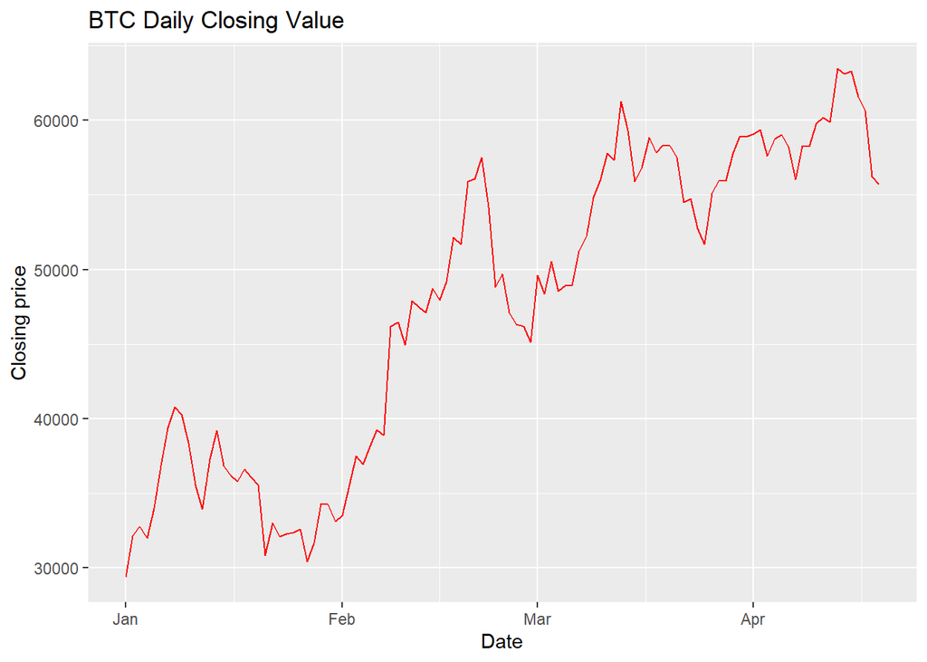

```r
BTCN$Close <- ts(BTCN$Close)
BTCN$Date <- seq.Date(as.Date('2021-01-01'), by = 'day', length.out = length(BTCN$Close))

ggplot(BTCN, aes(y = Close, x = Date)) + geom_line(col = 'red') +
  labs(title = 'BTC Daily Closing Value', y = 'Closing price')
```

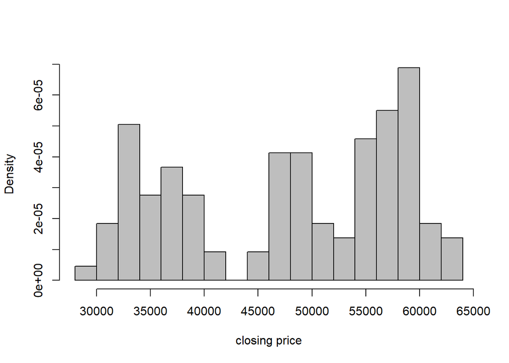

```r
hist(BTCN$Close, main="", breaks=20, freq=FALSE, col="grey", xlab = "closing price")
```

## (3) ANALYSIS

### Computation of ARCH 1 model

To perform the test for ARCH effects, we must

```r
# Step 1: Estimate mean equation r = beta + error
BTCN.mean <- dynlm(Close ~ 1, data = BTCN)

# Step 2: Retrieve the residuals from the former model and square them
ehatsq <- ts(resid(BTCN.mean)^2)

# Step 3: regress squared residuals on one-lagged squared residuals
BTCN.arch <- dynlm(ehatsq ~ L(ehatsq), data = ehatsq)

summary(BTCN.arch)
```

```
##
## Time series regression with "ts" data:
## Start = 2, End = 109
##
## Call:
## dynlm(formula = ehatsq ~ L(ehatsq), data = ehatsq)
##
## Residuals:
##       Min        1Q    Median        3Q       Max
## -84264028 -16822682  -3032740  18022583 146384121
##
## Coefficients:
##              Estimate Std. Error t value Pr(>|t|)
## (Intercept) 1.225e+07  5.647e+06    2.17   0.0323 *
## L(ehatsq)   8.593e-01  4.224e-02   20.34   <2e-16 ***
## ---
## Signif. codes:  0 '***' 0.001 '**' 0.01 '*' 0.05 '.' 0.1 ' ' 1
##
## Residual standard error: 36220000 on 106 degrees of freedom
## Multiple R-squared:  0.7961, Adjusted R-squared:  0.7942
## F-statistic: 413.8 on 1 and 106 DF,  p-value: < 2.2e-16
```

We can check for ARCH effects by using the ArchTest() function from the FinTS package. We will use a significance level of $\alpha=0.05$ for our null hypothesis test.

```r
btcn.archTest <- ArchTest(BTCN$Close, lags = 1, demean = TRUE)
btcn.archTest
```

```
##
##  ARCH LM-test; Null hypothesis: no ARCH effects
##
## data:  BTCN$Close
## Chi-squared = 85.977, df = 1, p-value < 2.2e-16
```

Because the p-value is < 0.05, we reject the null hypothesis and conclude the presence of ARCH(1) effects.

**Estimating ARCH Models**

```r
arch.fit <- garchFit(~garch(1,0), data = BTCN$Close, trace = F)
summary(arch.fit)
```

```
##
## Title:
##  GARCH Modelling
##
## Call:
##  garchFit(formula = ~garch(1, 0), data = BTCN$Close, trace = F)
##
## Mean and Variance Equation:
##  data ~ garch(1, 0)
## <environment: 0x0000000018c0fbe8>
##  [data = BTCN$Close]
##
## Conditional Distribution:
##  norm
##
## Coefficient(s):
##         mu       omega      alpha1
## 5.7029e+04  2.7982e+06  9.4411e-01
##
## Std. Errors:
##  based on Hessian
##
## Error Analysis:
##         Estimate  Std. Error  t value Pr(>|t|)
## mu     5.703e+04   5.532e+02  103.091  < 2e-16 ***
## omega  2.798e+06   9.202e+05    3.041  0.00236 **
## alpha1 9.441e-01   1.536e-01    6.146 7.95e-10 ***
## ---
## Signif. codes:  0 '***' 0.001 '**' 0.01 '*' 0.05 '.' 0.1 ' ' 1
##
## Log Likelihood:
##  -1121.925    normalized:  -10.29289
##
## Description:
##  Fri Apr 30 00:50:11 2021 by user: dhruv
##
##
## Standardised Residuals Tests:
##                                 Statistic p-Value
##  Jarque-Bera Test   R    Chi^2  17.96611  0.0001255185
##  Shapiro-Wilk Test  R    W      0.8717325 2.968879e-08
##  Ljung-Box Test     R    Q(10)  285.7412  0
##  Ljung-Box Test     R    Q(15)  335.4929  0
##  Ljung-Box Test     R    Q(20)  368.8932  0
##  Ljung-Box Test     R^2  Q(10)  6.288177  0.7904987
##  Ljung-Box Test     R^2  Q(15)  12.41204  0.6476112
##  Ljung-Box Test     R^2  Q(20)  24.97331  0.2024542
##  LM Arch Test       R    TR^2   9.901879  0.6245685
##
## Information Criterion Statistics:
##      AIC      BIC      SIC     HQIC
## 20.64083 20.71490 20.63937 20.67087
```

Plotting the conditional variance looks something like

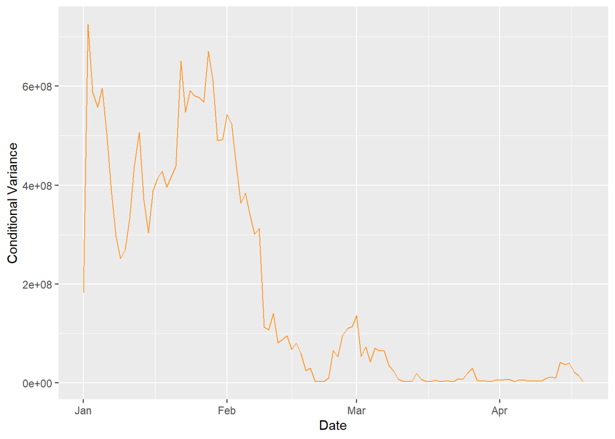

```r
BTCN$ht <- arch.fit@h.t
ggplot(BTCN, aes(y = ht, x = Date)) + geom_line(col = '#ff9933') + ylab('Conditional Variance') + xlab('Date')
```

Look at the graph, we can see that Jan and Feb have high volatility.

## (4) MODEL EVALUATION

### Prediction and Model accuracy

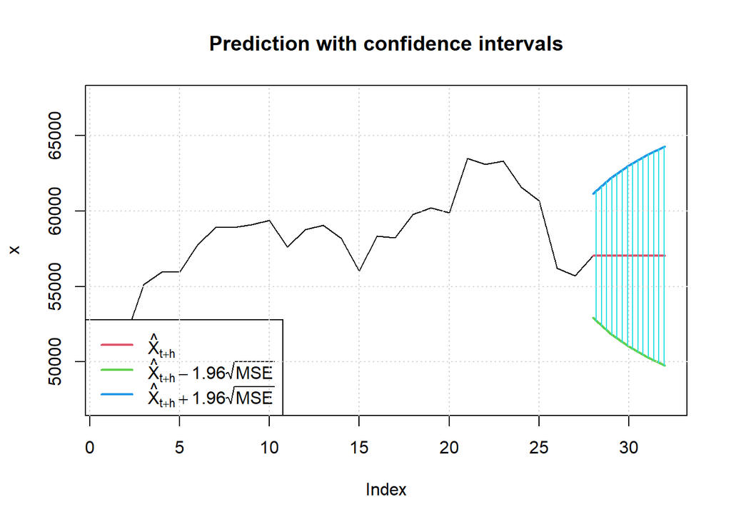

```
##   meanForecast meanError standardDeviation lowerInterval upperInterval
## 1     57028.67  2098.706          2098.706      52915.28      61142.06
## 2     57028.67  2637.534          2637.534      51859.20      62198.14
## 3     57028.67  3060.387          3060.387      51030.42      63026.92
## 4     57028.67  3411.846          3411.846      50341.57      63715.76
## 5     57028.67  3713.257          3713.257      49750.82      64306.52
```

```r
predict(arch.fit, n.ahead = 5, mse ="cond", plot = T)
```

## (5) CONCLUSION

### Summary

The ARCH model is a common statistical model for time series analysis and is widely used in economics and finance. It describes the variance of a temporal variable, and if the conditional variance of this variable has some correlation with itself (in the past), then we say there exists an ARCH effect.

Here in our essay, we have investigated the volatility of Bitcoin (BTC) from January 2021 to the present (April 19th). We apply the Generalized ARCH model (GARCH) in this real-time real-life example from the Yahoo finance source.

In terms of our BTC-USD dataset, we observed that Bitcoin, as a decentralized currency, is highly volatile and the value can rise or drop very quickly over a short amount of time. Given the previous bitcoin values, the future values are very difficult to predict due to this high volatility and conditional variance, as the ARCH model indicates.

Overall the ARCH model is mathematically explainable and a very powerful tool to model financial time series.

## (6) REFERENCES

https://github.com/ccolonescu/PoEdata

https://finance.yahoo.com/quote/BTC-USD?p=BTC-USD

https://rpubs.com/cyobero/arch

https://bookdown.org/ccolonescu/RPoE4/time-varying-volatility-and-arch-models.html